# matplotlib.axes.Axes.margins

**Axes.margins(*margins, *x=None*, *y=None*, *tight=True*)[[source]](https://github.com/matplotlib/matplotlib/blob/v3.10.8/lib/matplotlib/axes/_base.py#L2811-L2891)**

Set or retrieve margins around the data for autoscaling axis limits.

This allows to configure the padding around the data without having to set explicit limits using `set_xlim` / `set_ylim`.

Autoscaling determines the axis limits by adding *margin* times the data interval as padding around the data. See the following illustration:

([`Source code`](https://matplotlib.org/stable/_downloads/ad69cec3e927b3cd3dd5828130cb83c7/axes_margins.py), [`2x.png`](https://matplotlib.org/stable/_downloads/c13514a334ab068a54005473c27f2179/axes_margins.2x.png), [`png`](https://matplotlib.org/stable/_downloads/d90eb9f14ec19e4599252b9c8edefd38/axes_margins.png))

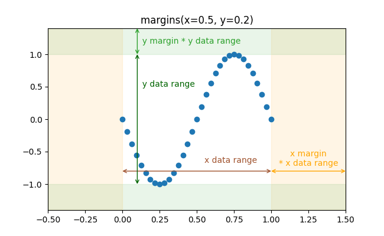

All input parameters must be floats greater than -0.5. Passing both positional and keyword arguments is invalid and will raise a TypeError. If no arguments (positional or otherwise) are provided, the current margins will remain unchanged and simply be returned.

The default margins are `rcParams["axes.xmargin"]` (default: `0.05`) and `rcParams["axes.ymargin"]` (default: `0.05`).

**Parameters:**

**marginsfloat, optional**

If a single positional argument is provided, it specifies both margins of the x-axis and y-axis limits. If two positional arguments are provided, they will be interpreted as *xmargin*, *ymargin*. If setting the margin on a single axis is desired, use the keyword arguments described below.

**x, y**float, optional**

Specific margin values for the x-axis and y-axis, respectively. These cannot be used with positional arguments, but can be used individually to alter on e.g., only the y-axis.

**tight**bool or None, default: True**

The *tight* parameter is passed to `autoscale_view`, which is executed after a margin is changed; the default here is *True*, on the assumption that when margins are specified, no additional padding to match tick marks is usually desired. Setting *tight* to *None* preserves the previous setting.

**Returns:**

**xmargin, ymargin**float**

See also

**`Axes.set_xmargin`, `Axes.set_ymargin`**

#### Notes

If a previously used Axes method such as `pcolor()` has set `use_sticky_edges` to [`True`](https://docs.python.org/3/library/constants.html#True), only the limits not set by the "sticky artists" will be modified. To force all margins to be set, set `use_sticky_edges` to [`False`](https://docs.python.org/3/library/constants.html#False) before calling `margins()`.

## Examples using `matplotlib.axes.Axes.margins`

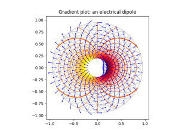

[Trigradient Demo](https://matplotlib.org/stable/gallery/images_contours_and_fields/trigradient_demo.html)

Trigradient Demo

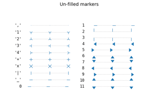

[Marker reference](https://matplotlib.org/stable/gallery/lines_bars_and_markers/marker_reference.html)

Marker reference

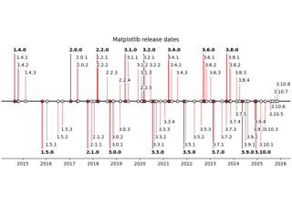

[Timeline with lines, dates, and text](https://matplotlib.org/stable/gallery/lines_bars_and_markers/timeline.html)

Timeline with lines, dates, and text

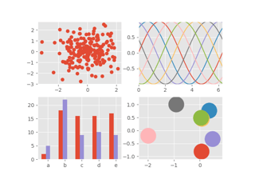

[ggplot style sheet](https://matplotlib.org/stable/gallery/style_sheets/ggplot.html)

ggplot style sheet

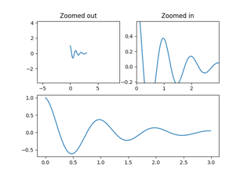

[Controlling view limits using margins and sticky_edges](https://matplotlib.org/stable/gallery/subplots_axes_and_figures/axes_margins.html)

Controlling view limits using margins and sticky_edges

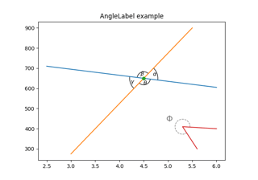

[Scale invariant angle label](https://matplotlib.org/stable/gallery/text_labels_and_annotations/angle_annotation.html)

Scale invariant angle label

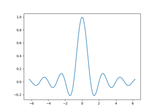

[Autoscaling Axis](https://matplotlib.org/stable/users/explain/axes/autoscale.html)

Autoscaling Axis

© 2012–2026 Matplotlib Development Team. All rights reserved.  
Licensed under the Matplotlib License Agreement.  
https://matplotlib.org/stable/api/_as_gen/matplotlib.axes.Axes.margins.html